# Project: TMDB Movie Data Analysis

- Introduction
- Data Wrangling
- Exploratory Data Analysis
- Conclusions

## Introduction

> This project is an analysis of the TMDB movies dataset which contains more than 10,000 records and a plethora of information about each movie.

> We will attempt to find trends of different movie properties and how they have changed over the years. We will also attempt to find the correlations -if any- between revenue and these properties. I am using revenue as the base of my analysis as this would be the most logical reason an analysis such as this would be valid in a real world scenario.

### Questions to answer:

> 1. Which movie generated the highest / lowest profits?
> 2. Which genres are most popular from year to year?
> 3. What kind of properties are associated with movies that have high revenues and high profits?
> 4. Which production companies produced the most movies over the years?
> 5. Which actors have the most movie appearances?

#### Resources used while working on this project

> [Changing scientific notation to standard numbers in Pandas](https://stackoverflow.com/questions/38689125/how-to-get-rid-of-pandas-converting-large-numbers-in-excel-sheet-to-exponential)

> [Finding different combinations of NaN values in DataFrame columns](https://stackoverflow.com/a/55449061/13318198)

> [Creating Pandas new column from others](https://stackoverflow.com/a/46570641/13318198)

> [Creating Pandas DataFrames from partial string match](https://stackoverflow.com/questions/49015376/creating-new-pandas-dataframe-from-partial-string-match)

> [Data visualization guide with Seaborn](https://www.kaggle.com/berkayalan/seaborn-a-complete-data-visualization-guide)

> [Seaborn correlation heatmap](https://stackoverflow.com/a/66506646/13318198)

> [Pandas official reference - string methods](https://pandas.pydata.org/docs/reference/api/pandas.Series.str.get_dummies.html)

> [Extract column value based on another column in Pandas](https://stackoverflow.com/questions/36684013/extract-column-value-based-on-another-column-pandas-dataframe)

> [Seaborn official tutorial - color palettes](https://seaborn.pydata.org/tutorial/color_palettes.html)

```python
import numpy as np
import pandas as pd
import matplotlib.pyplot as plt
import seaborn as sns
%matplotlib inline

# Pandas are showing some columns with scientific notation. This option is changing that to numeric values

# pd.options.display.float_format = '{:.2f}'.format
```

## Data Wrangling

### General Properties

###### In this section we will:

> 1. Load the data
> 2. Inspect the first few lines of data
> 3. Know what is the shape of this data *(rows, columns)*
> 4. Get information about datatypes of each column
> 5. Find missing values
> 6. Find erroneous values
> 7. Find duplicate rows

```python
df = pd.read_csv('tmdb-movies.csv')
```

```python
df.head(2)
```

|  | id | imdb_id | popularity | budget | revenue | original_title | cast | homepage | director | tagline | ... | overview | runtime | genres | production_companies | release_date | vote_count | vote_average | release_year | budget_adj | revenue_adj |
| --- | --- | --- | --- | --- | --- | --- | --- | --- | --- | --- | --- | --- | --- | --- | --- | --- | --- | --- | --- | --- | --- |
| 0 | 135397 | tt0369610 | 32.985763 | 150000000 | 1513528810 | Jurassic World | Chris Pratt\|Bryce Dallas Howard\|Irrfan Khan\|Vi... | http://www.jurassicworld.com/ | Colin Trevorrow | The park is open. | ... | Twenty-two years after the events of Jurassic ... | 124 | Action\|Adventure\|Science Fiction\|Thriller | Universal Studios\|Amblin Entertainment\|Legenda... | 6/9/15 | 5562 | 6.5 | 2015 | 1.379999e+08 | 1.392446e+09 |
| 1 | 76341 | tt1392190 | 28.419936 | 150000000 | 378436354 | Mad Max: Fury Road | Tom Hardy\|Charlize Theron\|Hugh Keays-Byrne\|Nic... | http://www.madmaxmovie.com/ | George Miller | What a Lovely Day. | ... | An apocalyptic story set in the furthest reach... | 120 | Action\|Adventure\|Science Fiction\|Thriller | Village Roadshow Pictures\|Kennedy Miller Produ... | 5/13/15 | 6185 | 7.1 | 2015 | 1.379999e+08 | 3.481613e+08 |

2 rows × 21 columns

```python
df.tail(2)
```

|  | id | imdb_id | popularity | budget | revenue | original_title | cast | homepage | director | tagline | ... | overview | runtime | genres | production_companies | release_date | vote_count | vote_average | release_year | budget_adj | revenue_adj |
| --- | --- | --- | --- | --- | --- | --- | --- | --- | --- | --- | --- | --- | --- | --- | --- | --- | --- | --- | --- | --- | --- |
| 10864 | 21449 | tt0061177 | 0.064317 | 0 | 0 | What's Up, Tiger Lily? | Tatsuya Mihashi\|Akiko Wakabayashi\|Mie Hama\|Joh... | NaN | Woody Allen | WOODY ALLEN STRIKES BACK! | ... | In comic Woody Allen's film debut, he took the... | 80 | Action\|Comedy | Benedict Pictures Corp. | 11/2/66 | 22 | 5.4 | 1966 | 0.000000 | 0.0 |
| 10865 | 22293 | tt0060666 | 0.035919 | 19000 | 0 | Manos: The Hands of Fate | Harold P. Warren\|Tom Neyman\|John Reynolds\|Dian... | NaN | Harold P. Warren | It's Shocking! It's Beyond Your Imagination! | ... | A family gets lost on the road and stumbles up... | 74 | Horror | Norm-Iris | 11/15/66 | 15 | 1.5 | 1966 | 127642.279154 | 0.0 |

2 rows × 21 columns

> At first glance, the head of the dataset provides some ideas for cleaning the data:
> - There are some columns that are probably irrelevant for the purpose of this analysis
> - Data in columns `budget_adj` and `revenue_adj` is displayed as scientific notation, which is not easy to read
> - Data in columns `production_companies` and `genres` consist of multiple values separated by `|`
> - There are some zero values in `budget`, `revenue`, `budget_adj`, and `revenue_adj`. We need to convert these values to NaN and do a uniform drop for all of them.

```python
df.info()
```

```
<class 'pandas.core.frame.DataFrame'>
RangeIndex: 10866 entries, 0 to 10865
Data columns (total 21 columns):
 #   Column                Non-Null Count  Dtype
---  ------                --------------  -----
 0   id                    10866 non-null  int64
 1   imdb_id               10856 non-null  object
 2   popularity            10866 non-null  float64
 3   budget                10866 non-null  int64
 4   revenue               10866 non-null  int64
 5   original_title        10866 non-null  object
 6   cast                  10790 non-null  object
 7   homepage              2936 non-null   object
 8   director              10822 non-null  object
 9   tagline               8042 non-null   object
 10  keywords              9373 non-null   object
 11  overview              10862 non-null  object
 12  runtime               10866 non-null  int64
 13  genres                10843 non-null  object
 14  production_companies  9836 non-null   object
 15  release_date          10866 non-null  object
 16  vote_count            10866 non-null  int64
 17  vote_average          10866 non-null  float64
 18  release_year          10866 non-null  int64
 19  budget_adj            10866 non-null  float64
 20  revenue_adj           10866 non-null  float64
dtypes: float64(4), int64(6), object(11)
memory usage: 1.7+ MB
```

> We will likely need to change some column types. The most obvious candidate is `release_date`.

> Also, most missing values are in columns irrelevant to our analysis, so we will drop them.

```python
# Summing up NaN values in columns

df.isna().sum()
```

```
id                         0
imdb_id                   10
popularity                 0
budget                     0
revenue                    0
original_title             0
cast                      76
homepage                7930
director                  44
tagline                 2824
keywords                1493
overview                   4
runtime                    0
genres                    23
production_companies    1030
release_date               0
vote_count                 0
vote_average               0
release_year               0
budget_adj                 0
revenue_adj                0
dtype: int64
```

```python
df.describe()
```

|  | id | popularity | budget | revenue | runtime | vote_count | vote_average | release_year | budget_adj | revenue_adj |
| --- | --- | --- | --- | --- | --- | --- | --- | --- | --- | --- |
| count | 10866.000000 | 10866.000000 | 1.086600e+04 | 1.086600e+04 | 10866.000000 | 10866.000000 | 10866.000000 | 10866.000000 | 1.086600e+04 | 1.086600e+04 |
| mean | 66064.177434 | 0.646441 | 1.462570e+07 | 3.982332e+07 | 102.070863 | 217.389748 | 5.974922 | 2001.322658 | 1.755104e+07 | 5.136436e+07 |
| std | 92130.136561 | 1.000185 | 3.091321e+07 | 1.170035e+08 | 31.381405 | 575.619058 | 0.935142 | 12.812941 | 3.430616e+07 | 1.446325e+08 |
| min | 5.000000 | 0.000065 | 0.000000e+00 | 0.000000e+00 | 0.000000 | 10.000000 | 1.500000 | 1960.000000 | 0.000000e+00 | 0.000000e+00 |
| 25% | 10596.250000 | 0.207583 | 0.000000e+00 | 0.000000e+00 | 90.000000 | 17.000000 | 5.400000 | 1995.000000 | 0.000000e+00 | 0.000000e+00 |
| 50% | 20669.000000 | 0.383856 | 0.000000e+00 | 0.000000e+00 | 99.000000 | 38.000000 | 6.000000 | 2006.000000 | 0.000000e+00 | 0.000000e+00 |
| 75% | 75610.000000 | 0.713817 | 1.500000e+07 | 2.400000e+07 | 111.000000 | 145.750000 | 6.600000 | 2011.000000 | 2.085325e+07 | 3.369710e+07 |
| max | 417859.000000 | 32.985763 | 4.250000e+08 | 2.781506e+09 | 900.000000 | 9767.000000 | 9.200000 | 2015.000000 | 4.250000e+08 | 2.827124e+09 |

> After further investigation, it seems there are some `0` values in `budget`, `revenue`, `runtime`, `budget_adj`, and `revenue_adj`

> We will deal with these values later after removal of irrelevant columns

### Data Cleaning

###### In this section, we are going to perform the following operations on our dataset:

> 1. Dropping irrelevant columns
> 2. Dropping duplicate rows
> 3. Changing the type of `release_date` column into datetime format
> 4. Replacing `0` values with `NaN`, then dropping rows with `NaN` values
> 5. Adding `profit` column that is the difference between `revenue_adj` and `budget_adj`

```python
df.drop(['id', 'imdb_id', 'homepage', 'tagline', 'keywords', 'overview', 'budget', 'revenue'], axis=1, inplace=True)
df.shape
```

```
(10866, 13)
```

> At first glance, dropping `budget` and `revenue` columns may look like a mistake. However, these columns are redundant and misleading for the purpose of our analysis as they provide values that do not compare well across the span of production years. So we will drop them and rely on `budget_adj` and `revenue_adj` columns for comparable values.

```python
# It looks like only one row was considered duplicated and dropped, we will have to investigate more after further cleaning

df.drop_duplicates(inplace=True, ignore_index=True)
df.shape
```

```
(10865, 13)
```

```python
duplicate_titles = df[df['original_title'].duplicated()]
duplicate_titles.sort_values('original_title').head(10)
```

|  | popularity | original_title | cast | director | runtime | genres | production_companies | release_date | vote_count | vote_average | release_year | budget_adj | revenue_adj |
| --- | --- | --- | --- | --- | --- | --- | --- | --- | --- | --- | --- | --- | --- |
| 5747 | 0.336081 | 1 | Rhys Wakefield\|Logan Miller\|Ashley Hinshaw\|Nat... | Dennis Iliadis | 95 | Thriller\|Science Fiction | Process Productions | 9/20/13 | 49 | 5.1 | 2013 | 0.000000e+00 | 0.000000e+00 |
| 6513 | 0.128484 | 9 | NaN | Shane Acker | 11 | Animation\|Fantasy | NaN | 4/21/05 | 49 | 7.3 | 2005 | 0.000000e+00 | 0.000000e+00 |
| 7916 | 0.542315 | A Christmas Carol | George C. Scott\|Roger Rees\|David Warner\|Susann... | Clive Donner | 100 | TV Movie\|Fantasy\|Drama\|Comedy\|Family | Entertainment Partners Ltd. | 12/17/84 | 29 | 6.6 | 1984 | 0.000000e+00 | 0.000000e+00 |
| 2488 | 0.521573 | A Christmas Carol | Patrick Stewart\|Richard E. Grant\|Joel Grey\|Ian... | David Hugh Jones | 95 | Drama\|Fantasy | Turner Network Television (TNT)\|Hallmark Enter... | 12/5/99 | 23 | 6.1 | 1999 | 0.000000e+00 | 0.000000e+00 |
| 7890 | 1.331432 | A Nightmare on Elm Street | John Saxon\|Ronee Blakley\|Heather Langenkamp\|Am... | Wes Craven | 91 | Horror | New Line Cinema\|Smart Egg Pictures | 11/15/84 | 625 | 7.1 | 1984 | 3.778276e+06 | 5.353504e+07 |
| 10852 | 0.163592 | Alfie | Michael Caine\|Shelley Winters\|Millicent Martin... | Lewis Gilbert | 114 | Comedy\|Drama\|Romance | NaN | 3/29/66 | 26 | 6.2 | 1966 | 0.000000e+00 | 0.000000e+00 |
| 10029 | 0.420512 | Alice | Mia Farrow\|William Hurt\|Joe Mantegna\|Alec Bald... | Woody Allen | 102 | Comedy\|Drama\|Romance | Orion Pictures | 12/25/90 | 22 | 5.9 | 1990 | 0.000000e+00 | 0.000000e+00 |
| 2561 | 0.253305 | Alice in Wonderland | Tina Majorino\|Robbie Coltrane\|Ben Kingsley\|Mir... | Nick Willing | 150 | Fantasy\|Family | NBC\|Hallmark Entertainment | 2/28/99 | 39 | 6.3 | 1999 | 2.749011e+07 | 0.000000e+00 |
| 6140 | 0.350256 | Alice in Wonderland | Natalie Gregory\|Sheila Allen\|Sharee Gregory\|Re... | Harry Harris | 187 | Fantasy\|Family | NaN | 12/9/85 | 13 | 6.2 | 1985 | 0.000000e+00 | 0.000000e+00 |
| 10685 | 0.080626 | And Soon the Darkness | Pamela Franklin\|Michele Dotrice\|Sandor ElÃ¨s\|J... | Robert Fuest | 99 | Mystery\|Thriller | EMI Films Ltd. | 9/10/70 | 10 | 7.5 | 1970 | 0.000000e+00 | 0.000000e+00 |

> After further investigation of duplicates based on movie titles, it looks like there are movies with the same title but have different casts, directors, release dates, and/or production companies, so they are unique movies, not duplicates.

```python
# Changing `release_date` into datetime format

df['release_date'] = pd.to_datetime(df['release_date'])
```

```python
# Checking operation success

df.info()
```

```
<class 'pandas.core.frame.DataFrame'>
RangeIndex: 10865 entries, 0 to 10864
Data columns (total 13 columns):
 #   Column                Non-Null Count  Dtype
---  ------                --------------  -----
 0   popularity            10865 non-null  float64
 1   original_title        10865 non-null  object
 2   cast                  10789 non-null  object
 3   director              10821 non-null  object
 4   runtime               10865 non-null  int64
 5   genres                10842 non-null  object
 6   production_companies  9835 non-null   object
 7   release_date          10865 non-null  datetime64[ns]
 8   vote_count            10865 non-null  int64
 9   vote_average          10865 non-null  float64
 10  release_year          10865 non-null  int64
 11  budget_adj            10865 non-null  float64
 12  revenue_adj           10865 non-null  float64
dtypes: datetime64[ns](1), float64(4), int64(3), object(5)
memory usage: 1.1+ MB
```

```python
# Replacing zero values with NaN

df['runtime'].replace(0, np.NAN, inplace=True)
df['budget_adj'].replace(0, np.NAN, inplace=True)
df['revenue_adj'].replace(0, np.NAN, inplace=True)
```

```python
# Checking if above operation is successful

df.isna().sum()
```

```
popularity                 0
original_title             0
cast                      76
director                  44
runtime                   31
genres                    23
production_companies    1030
release_date               0
vote_count                 0
vote_average               0
release_year               0
budget_adj              5696
revenue_adj             6016
dtype: int64
```

```python
# Dropping NaN Values and checking if operation is successful

df.dropna(axis=0, how='any', inplace=True)
df.isna().sum()
```

```
popularity              0
original_title          0
cast                    0
director                0
runtime                 0
genres                  0
production_companies    0
release_date            0
vote_count              0
vote_average            0
release_year            0
budget_adj              0
revenue_adj             0
dtype: int64
```

```python
# Creating a profit column with the differenc between revenue_adj and budget_adj
df['profit'] = df.apply(lambda row: row.revenue_adj - row.budget_adj, axis=1)
df.head(3)
```

|  | popularity | original_title | cast | director | runtime | genres | production_companies | release_date | vote_count | vote_average | release_year | budget_adj | revenue_adj | profit |
| --- | --- | --- | --- | --- | --- | --- | --- | --- | --- | --- | --- | --- | --- | --- |
| 0 | 32.985763 | Jurassic World | Chris Pratt\|Bryce Dallas Howard\|Irrfan Khan\|Vi... | Colin Trevorrow | 124.0 | Action\|Adventure\|Science Fiction\|Thriller | Universal Studios\|Amblin Entertainment\|Legenda... | 2015-06-09 | 5562 | 6.5 | 2015 | 1.379999e+08 | 1.392446e+09 | 1.254446e+09 |
| 1 | 28.419936 | Mad Max: Fury Road | Tom Hardy\|Charlize Theron\|Hugh Keays-Byrne\|Nic... | George Miller | 120.0 | Action\|Adventure\|Science Fiction\|Thriller | Village Roadshow Pictures\|Kennedy Miller Produ... | 2015-05-13 | 6185 | 7.1 | 2015 | 1.379999e+08 | 3.481613e+08 | 2.101614e+08 |
| 2 | 13.112507 | Insurgent | Shailene Woodley\|Theo James\|Kate Winslet\|Ansel... | Robert Schwentke | 119.0 | Adventure\|Science Fiction\|Thriller | Summit Entertainment\|Mandeville Films\|Red Wago... | 2015-03-18 | 2480 | 6.3 | 2015 | 1.012000e+08 | 2.716190e+08 | 1.704191e+08 |

## Exploratory Data Analysis

> In this section, after cleaning the data, I will answer the questions posed at the start of this report

### Research Question 1: Which movie generated the highest / lowest profits?

```python
df.original_title[df['profit'] == df['profit'].max()]
```

```
1329    Star Wars
Name: original_title, dtype: object
```

```python
df['profit'].max()
```

```
2750136650.919176
```

###### Star Wars generated the highest profit with 2,750,136,651 USD.

```python
df.original_title[df['profit'] == df['profit'].min()]
```

```
2243    The Warrior's Way
Name: original_title, dtype: object
```

```python
df['profit'].min()
```

```
-413912431.0
```

###### On the other hand, The Warrior's Way suffered a **loss** of 413,912,431 USD.

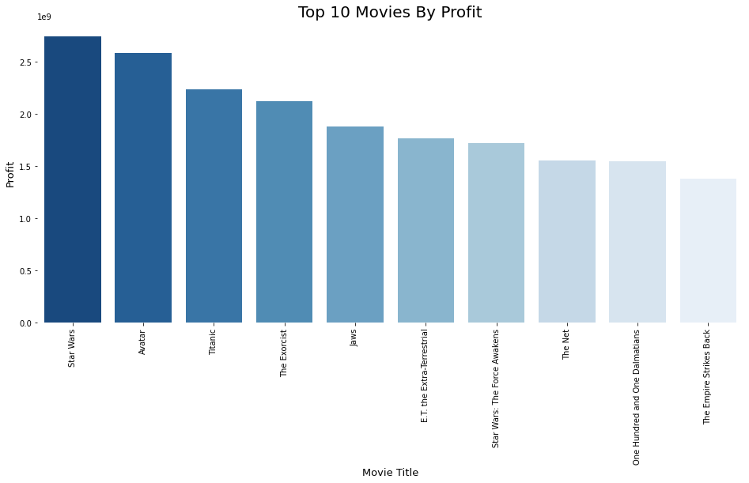

```python
plt.figure(figsize= (16,7))
top_10 = df[['original_title', 'profit']].sort_values('profit', ascending=False)[:10]
sns.barplot(x='original_title', y='profit', data=top_10, palette='Blues_r')
plt.xlabel('Movie Title', fontsize=13)
plt.ylabel('Profit', fontsize=13)
plt.title('Top 10 Movies By Profit', fontsize=20)
sns.despine(left=True, bottom=True)
plt.xticks(rotation=90)
plt.show()
```

###### In the above cell, I sorted the dataset by profit in descending order, then extracted the 10 highest profitable movies into

###### a mask, then created and customized a plot to show the profits for them side-by-side.

```python
pop_genres = df['genres'].str.get_dummies(sep='|')
pop_genres_1 = pop_genres.sum().reset_index()
```

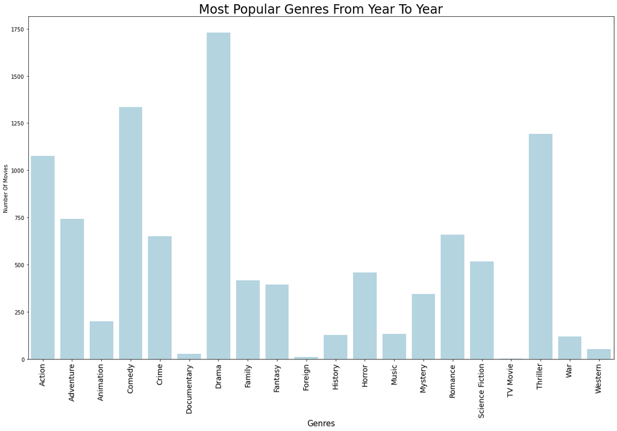

```python
plt.figure(figsize=(20, 12))
sns.barplot(x=pop_genres.columns, y=pop_genres.sum(), data=pop_genres_1, color='#ADD8E6')
plt.title('Most Popular Genres From Year To Year', fontsize=24)
plt.xlabel('Genres', fontsize=15)
plt.ylabel('Number Of Movies')
plt.xticks(rotation=90, fontsize= 14)
plt.show()
```

### Research Question 3: What kind of properties are associated with movies that have high revenues and profits?

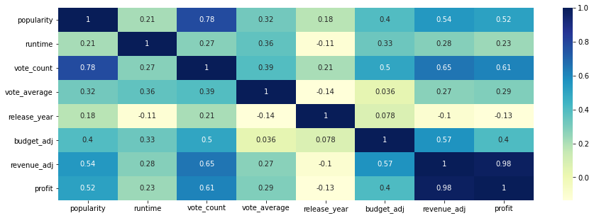

```python
plt.figure(figsize=(15,5))
corr = df.corr()
sns.heatmap(corr, cmap="YlGnBu", annot=True)
plt.show()
```

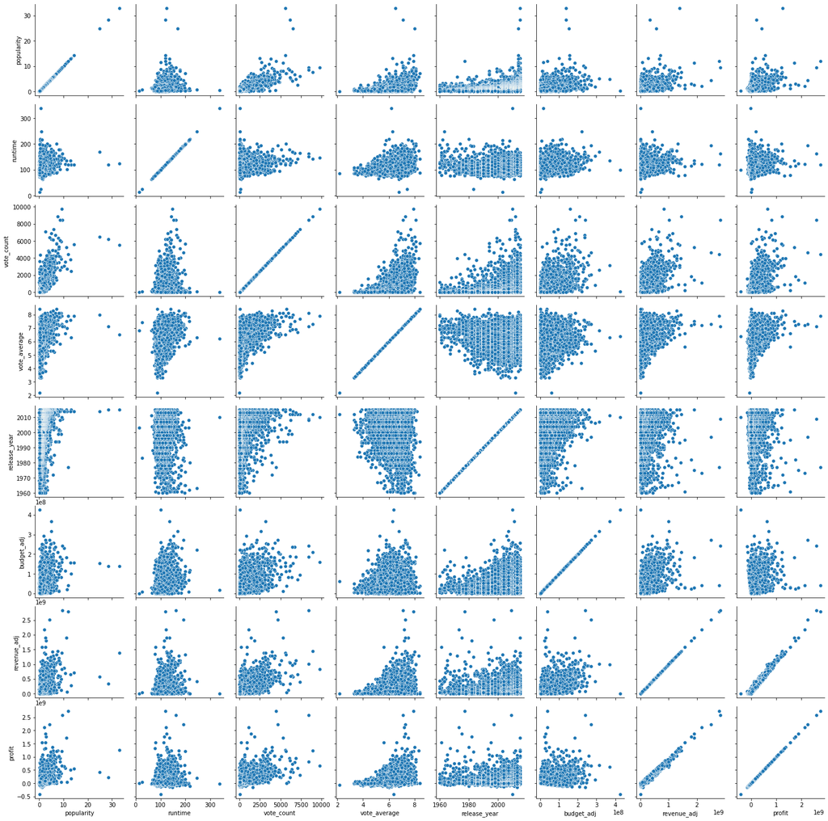

```python
g = sns.PairGrid(df)
g.map(sns.scatterplot);
```

###### As we can see from the above graph, the properties with the biggest correlation to high profits / revenues, respectively, are:

###### 1. Vote counts

###### 2. Popularity

###### 3. Budget

> This shows that movies with bigger budgets are more likely to generate higher revenues and, naturally, higher profits. The correlation between the success of a movie at generating profits and its budget is feasible, given than higher budgets usually contain higher allocation to advertisement than movies with lower budgets.

> **Important note:** *The high correlation between profit and revenue of a particular movie is expected, provided that production companies usually don't go overboard with a budget to make a non-profitable movie.*

### Research Question 4: Which production companies produced the most movies over the years?

```python
prod = df['production_companies'].str.get_dummies(sep='|')
```

```python
prod_1 = prod[prod.columns].apply(lambda x: sum(x.values))
prod_1 = prod_1.sort_values(ascending=False)[:10]
prod_1
```

```
Universal Pictures                        329
Warner Bros.                              324
Paramount Pictures                        270
Twentieth Century Fox Film Corporation    201
Columbia Pictures                         178
New Line Cinema                           152
Walt Disney Pictures                      117
Touchstone Pictures                       116
Metro-Goldwyn-Mayer (MGM)                 109
Relativity Media                          102
dtype: int64
```

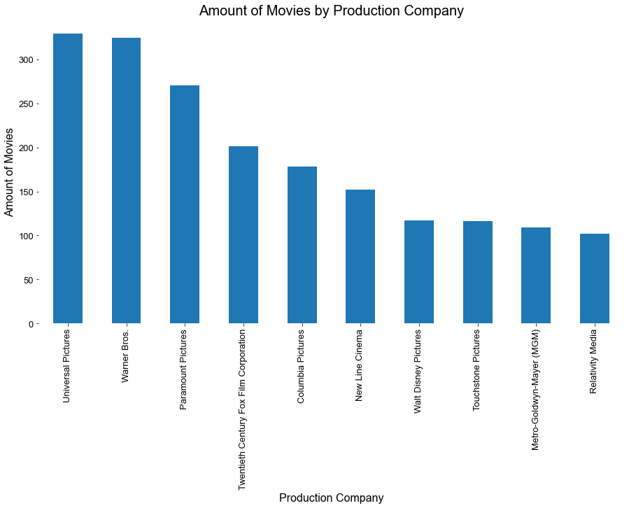

```python
plt.title('Amount of Movies by Production Company', fontsize=20)
plt.xlabel('Production Company', fontsize=16)
plt.ylabel('Amount of Movies', fontsize=16)
prod_1.plot(figsize=(15,8), kind='bar')
plt.xticks(rotation=90, fontsize= 13)
plt.yticks(fontsize= 13)
sns.set_style('whitegrid')
sns.despine(left=True, bottom=True)
plt.show()
```

> The above graph shows the ten companies that produced the most movies over the years while the top 3 companies being Universal Pictures, Warner Bros, and Paramount Pictures, having a notecable lead in the sheer amount of productions in comparison to other companies.

### Research Question 5: Which actors have the most movie appearances?

```python
cast = df['cast'].str.get_dummies(sep='|')
```

```python
cast_1 = cast[cast.columns].apply(lambda x: sum(x.values))
cast_1 = cast_1.sort_values(ascending=False)[:10]
cast_1
```

```
Robert De Niro        52
Bruce Willis          46
Samuel L. Jackson     44
Nicolas Cage          43
Matt Damon            36
Johnny Depp           35
Tom Hanks             34
Harrison Ford         34
Morgan Freeman        34
Sylvester Stallone    34
dtype: int64
```

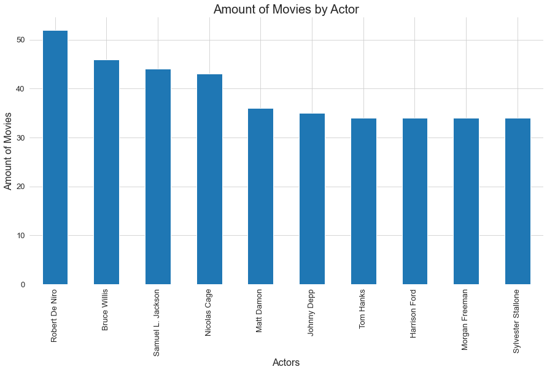

```python
plt.title('Amount of Movies by Actor', fontsize=20)
plt.xlabel('Actors', fontsize=16)
plt.ylabel('Amount of Movies', fontsize=16)
cast_1.plot(figsize=(15,8), kind='bar')
plt.xticks(rotation=90, fontsize= 13)
plt.yticks(fontsize= 13)
sns.despine(left=True, bottom=True)
sns.set_style('whitegrid')
plt.show()
```

> The above graph shows the ten actors that acted in the most movies over the years. The top 3 are Robert De Niro, Bruce Willis, and Samuel L. Jackson, respectively.

## Conclusions

### Limitations

> 1. The findings are not ironclad, it is based on the information provided by the dataset and could differ, for example if other variables were introduced.
> 2. Dropped values could have changed findings drastically, especially as the number of movie records (rows) that was dropped due to missing values is significantly higher than the records used in this analysis.